# Shark Attacks

Jonia Cook

2026-04-21

## Introduction

I grew up watching the Jaws movies. When I was older I remember hearing that those movies resulted in people hunting sharks, which greatly reduced the shark population. In recent years, there seem to be a lot more shark attacks on the news. This made me curious if shark attacks really did go down, and if they are starting to go back up. I downloaded the file that is maintainedn on the [Global Shark Attack File](https://www.sharkattackfile.net/incidentlog.htm) website.

## Shark Attacks Around the World

This is the plot I made of shark attacks around the world, from 1900 until now. This only shows attacks that have been recorded in the [Global Shark Attack File](https://www.sharkattackfile.net/incidentlog.htm) with a valid country attached to it. The data is actually grouped by decades to make the bars more visible; I just didn’t have time to figure out how to get the year to render correctly in the graph.

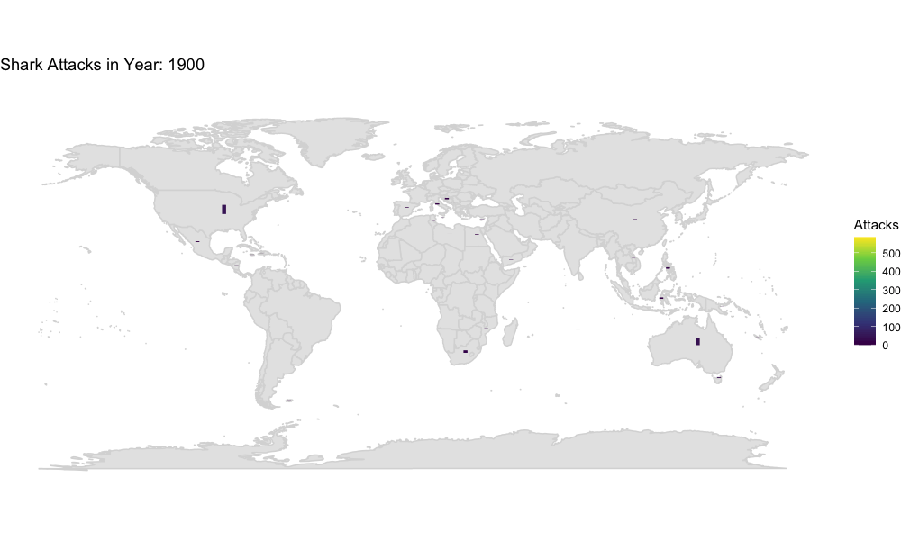

## Fatal Shark Attacks

I created several models to determine if age, gender, or time of day was a significant factor in whether or not the shark attack was fatal.

### Summary

This is the summary of my best fitting model.

```
##
## Call:
## glm(formula = Fatal_Bin ~ Age * Sex + Time_Category, family = "binomial",
##     data = my_sharks_countries)
##
## Coefficients:
##                       Estimate Std. Error z value Pr(>|z|)
## (Intercept)          -2.286430   0.249146  -9.177  < 2e-16 ***
## Age                   0.019166   0.006660   2.878  0.00400 **
## SexM                  0.626504   0.265489   2.360  0.01828 *
## SexU                  0.715418   0.955718   0.749  0.45412
## Time_CategoryEvening -0.258910   0.164785  -1.571  0.11614
## Time_CategoryMorning -0.017302   0.120783  -0.143  0.88609
## Time_CategoryNight    0.821463   0.277188   2.964  0.00304 **
## Time_CategoryUnknown  0.224720   0.108576   2.070  0.03848 *
## Age:SexM             -0.016122   0.007405  -2.177  0.02947 *
## Age:SexU             -0.003101   0.036389  -0.085  0.93209
## ---
## Signif. codes:  0 '***' 0.001 '**' 0.01 '*' 0.05 '.' 0.1 ' ' 1
##
## (Dispersion parameter for binomial family taken to be 1)
##
##     Null deviance: 3365.0  on 3595  degrees of freedom
## Residual deviance: 3334.4  on 3586  degrees of freedom
##   (2715 observations deleted due to missingness)
## AIC: 3354.4
##
## Number of Fisher Scoring iterations: 4
```

### Report

This is the report for this model

```
## We fitted a logistic model (estimated using ML) to predict Fatal_Bin with Age,
## Sex and Time_Category (formula: Fatal_Bin ~ Age * Sex + Time_Category). The
## model's explanatory power is very weak (Tjur's R2 = 8.87e-03). The model's
## intercept, corresponding to Age = 0, Sex = F and Time_Category = Afternoon, is
## at -2.29 (95% CI [-2.79, -1.81], p < .001). Within this model:
##
##   - The effect of Age is statistically significant and positive (beta = 0.02, 95%
## CI [6.01e-03, 0.03], p = 0.004; Std. beta = 0.28, 95% CI [0.09, 0.47])
##   - The effect of Sex [M] is statistically significant and positive (beta = 0.63,
## 95% CI [0.12, 1.16], p = 0.018; Std. beta = 0.17, 95% CI [-0.08, 0.44])
##   - The effect of Sex [U] is statistically non-significant and positive (beta =
## 0.72, 95% CI [-1.28, 2.56], p = 0.454; Std. beta = 0.63, 95% CI [-0.38, 1.53])
##   - The effect of Time Category [Evening] is statistically non-significant and
## negative (beta = -0.26, 95% CI [-0.59, 0.06], p = 0.116; Std. beta = -0.26, 95%
## CI [-0.59, 0.06])
##   - The effect of Time Category [Morning] is statistically non-significant and
## negative (beta = -0.02, 95% CI [-0.26, 0.22], p = 0.886; Std. beta = -0.02, 95%
## CI [-0.26, 0.22])
##   - The effect of Time Category [Night] is statistically significant and positive
## (beta = 0.82, 95% CI [0.26, 1.35], p = 0.003; Std. beta = 0.82, 95% CI [0.26,
## 1.35])
##   - The effect of Time Category [Unknown] is statistically significant and
## positive (beta = 0.22, 95% CI [0.01, 0.44], p = 0.038; Std. beta = 0.22, 95% CI
## [0.01, 0.44])
##   - The effect of Age × Sex [M] is statistically significant and negative (beta =
## -0.02, 95% CI [-0.03, -1.54e-03], p = 0.029; Std. beta = -0.24, 95% CI [-0.45,
## -0.02])
##   - The effect of Age × Sex [U] is statistically non-significant and negative
## (beta = -3.10e-03, 95% CI [-0.08, 0.07], p = 0.932; Std. beta = -0.05, 95% CI
## [-1.17, 1.02])
##
## Standardized parameters were obtained by fitting the model on a standardized
## version of the dataset. 95% Confidence Intervals (CIs) and p-values were
## computed using a Wald z-distribution approximation.
```

## Shark Attacks in Relation to the Movie ‘Jaws’

This is the graph I made that shows shark attacks around the world, before and after the movie ‘Jaws’ came out.

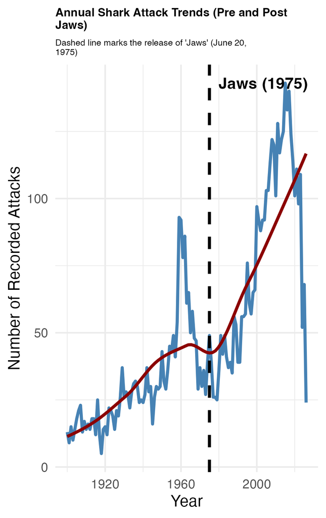

As you can see, shark attacks did drop sharply around the time ‘Jaws’ was released, but the decline appears to have happened before the movie came out. After the movie came out, shark attacks have started going back up again. There appears to have been another sharp drop that started around 2019, but the cause of that most likely has nothing to do with ‘Jaws’.